# Анализ факторов оттока клиентов фитнес-центра

В данном исследовании ставится цель проанализировать поведение клиентов фитнес-центра «Культурист-датасаентист» для формирования data-based рекомендаций к стратегии по работе с клиентами.

**Ключевые задачи исследования:**

- Выявления факторов, влияющих на вероятность ухода клиента.
- Кластеризация клиентов и подготовка "портретов" основных типов клиентов.
- Подготовка рекомендаций по 3 вопросам:

  ```
    - Какие целевые группы клиентов?
    - Какие меры могут быть приняты для снижения оттока клиентов?
    - Какие другие особенности взаимодействия с клиентами могут оказаться важными для заказчика?
  ```

Анализ базируется на данных из анкет клиентов с зафиксированным фактом отказа от услуг компании/сохранения статуса клиента.

План исследования приложен в нижеследующем разделе "Оглавление".

**Ключевые выводы:**

- Классификаторы выдали, что частота хождения на тренировки является важным индикатором, влияющим на уход клиента, при этом особенно важна частота хождения в текущем месяце, перед уходом она начинает падать. Также подтвердился очевидный вывод о том, что лояльные клиенты лояльнее: давно пользующиеся услугами фитнес-центра клиенты с меньшей вероятностью уйдут.
- Кластеризация прошла успешно, были выявлены 5 характерных типажей клиентов, описанный в соответствующем разделе исследования.
- Важнейшим направлением в работе с клиентами стоит считать расширение партнерских программ, так как клиенты из этой группы самые стабильные.
- Была выявлена "группа риска". С ней достаточно трудно работать, так как они не оставили номера своих мобильных телефонов. Однако, они посещают групповые тренировки, что может помочь. Также их можно выявлять заранее ввиду того, что они покупают длительные абонементы и, перед тем как бросить тренировки, начинают ходить реже. Именно в момент снижения среднего числа тренировок в неделю в их отношении необходимо принимать меры по удержанию.

**Оглавление:**

1. Открытие и первичный анализ данных
2. EDA
   - Обработка ошибок
   - Сравнение групп клиентов
   - Поиск корреляций
   - Промежуточный вывод
3. Модель прогнозирования оттока клиентов
   - Подготовка данных
   - Обучение моделей и оценка их метрик
   - Промежуточный вывод
4. Кластеризация клиентов
   - Стандартизация данных
   - Иерархическая кластеризация, оценка оптимального числа кластеров
   - Кластеризация методом K-means
   - Характеристики кластеров
   - Промежуточный вывод
5. Итоговый вывод

## Открытие и первичный анализ данных

```python
import pandas as pd
import matplotlib as mpl
import matplotlib.pyplot as plt
import numpy as np
import seaborn as sns
from scipy import stats as st
import datetime as dt
from sklearn.preprocessing import StandardScaler
from sklearn.model_selection import train_test_split
from sklearn.ensemble import RandomForestClassifier, GradientBoostingClassifier
from sklearn.ensemble import RandomForestRegressor
from sklearn.cluster import KMeans
from scipy.cluster.hierarchy import dendrogram, linkage
from sklearn.linear_model import LogisticRegression
from sklearn.metrics import accuracy_score, precision_score, recall_score, f1_score
from sklearn.metrics import roc_auc_score
from sklearn.metrics import roc_curve
import phik
from phik.report import plot_correlation_matrix
from phik import report
```

```python
sns.set(rc={'figure.figsize':(12,9)})
```

```python
pd.set_option('display.precision', 3)
pd.options.display.max_colwidth = 1
```

Подгружаем библиотеки

```python
gym = pd.read_csv('https://code.s3.yandex.net/datasets/gym_churn.csv')
```

```python
display(gym)
```

|  | gender | Near_Location | Partner | Promo_friends | Phone | Contract_period | Group_visits | Age | Avg_additional_charges_total | Month_to_end_contract | Lifetime | Avg_class_frequency_total | Avg_class_frequency_current_month | Churn |
| --- | --- | --- | --- | --- | --- | --- | --- | --- | --- | --- | --- | --- | --- | --- |
| 0 | 1 | 1 | 1 | 1 | 0 | 6 | 1 | 29 | 14.227 | 5.0 | 3 | 0.020 | 0.000 | 0 |
| 1 | 0 | 1 | 0 | 0 | 1 | 12 | 1 | 31 | 113.203 | 12.0 | 7 | 1.923 | 1.910 | 0 |
| 2 | 0 | 1 | 1 | 0 | 1 | 1 | 0 | 28 | 129.448 | 1.0 | 2 | 1.859 | 1.737 | 0 |
| 3 | 0 | 1 | 1 | 1 | 1 | 12 | 1 | 33 | 62.670 | 12.0 | 2 | 3.206 | 3.357 | 0 |
| 4 | 1 | 1 | 1 | 1 | 1 | 1 | 0 | 26 | 198.362 | 1.0 | 3 | 1.114 | 1.120 | 0 |
| ... | ... | ... | ... | ... | ... | ... | ... | ... | ... | ... | ... | ... | ... | ... |
| 3995 | 1 | 1 | 1 | 0 | 1 | 12 | 0 | 33 | 2.406 | 12.0 | 8 | 2.284 | 2.349 | 0 |
| 3996 | 0 | 1 | 0 | 0 | 1 | 1 | 1 | 29 | 68.884 | 1.0 | 1 | 1.277 | 0.293 | 1 |
| 3997 | 1 | 1 | 1 | 1 | 1 | 12 | 0 | 28 | 78.251 | 11.0 | 2 | 2.786 | 2.831 | 0 |
| 3998 | 0 | 1 | 1 | 1 | 1 | 6 | 0 | 32 | 61.913 | 5.0 | 3 | 1.630 | 1.596 | 0 |
| 3999 | 1 | 0 | 1 | 0 | 0 | 12 | 1 | 30 | 178.862 | 12.0 | 1 | 1.102 | 1.035 | 0 |

4000 rows × 14 columns

Подгружаем массивы

```python
gym.info()
```

```
<class 'pandas.core.frame.DataFrame'>
RangeIndex: 4000 entries, 0 to 3999
Data columns (total 14 columns):
 #   Column                             Non-Null Count  Dtype
---  ------                             --------------  -----
 0   gender                             4000 non-null   int64
 1   Near_Location                      4000 non-null   int64
 2   Partner                            4000 non-null   int64
 3   Promo_friends                      4000 non-null   int64
 4   Phone                              4000 non-null   int64
 5   Contract_period                    4000 non-null   int64
 6   Group_visits                       4000 non-null   int64
 7   Age                                4000 non-null   int64
 8   Avg_additional_charges_total       4000 non-null   float64
 9   Month_to_end_contract              4000 non-null   float64
 10  Lifetime                           4000 non-null   int64
 11  Avg_class_frequency_total          4000 non-null   float64
 12  Avg_class_frequency_current_month  4000 non-null   float64
 13  Churn                              4000 non-null   int64
dtypes: float64(4), int64(10)
memory usage: 437.6 KB
```

Итак, массив содержит данные о 4 тысячах клиентов. Предварительный анализ показывает отсутствие пропусков.

Вернуться к оглавлению

## EDA

В данном разделе мы проведем поиск дубликатов, пропущенных значений и других возможных ошибок.

Вернуться к оглавлению

### Обработка ошибок

Для начала изучим на факт наличия пропущенных значений

```python
def miss_table(data):
    missings = pd.DataFrame(data.isna().mean()*100, columns = ['% miss'])
    missings['# miss'] = pd.DataFrame(data.isna().sum())
    display (missings.style.background_gradient('coolwarm'))
```

```python
miss_table(gym)
```

|  | % miss | # miss |
| --- | --- | --- |
| gender | 0.000000 | 0 |
| Near_Location | 0.000000 | 0 |
| Partner | 0.000000 | 0 |
| Promo_friends | 0.000000 | 0 |
| Phone | 0.000000 | 0 |
| Contract_period | 0.000000 | 0 |
| Group_visits | 0.000000 | 0 |
| Age | 0.000000 | 0 |
| Avg_additional_charges_total | 0.000000 | 0 |
| Month_to_end_contract | 0.000000 | 0 |
| Lifetime | 0.000000 | 0 |
| Avg_class_frequency_total | 0.000000 | 0 |
| Avg_class_frequency_current_month | 0.000000 | 0 |
| Churn | 0.000000 | 0 |

Как уже упоминалось, пропусков в предоставленных данных нет.

```python
gym.duplicated().sum()
```

```
0
```

Дубликаты так же отсутствуют

```python
def des_var(data):
    for i in list(data):
        if (data[i].dtypes!='object') and (data[i].nunique() > 20):
             display (data[i].describe())
        else:
            display (data[i].value_counts())
        print ('------------------------------')
        print (' ')
```

Для изучения наших данных построим графики для категориальных значений и описательные статистики для непрерывных величин.

```python
des_var(gym)
```

```
1    2041
0    1959
Name: gender, dtype: int64
```

```
1    3381
0    619
Name: Near_Location, dtype: int64
```

```
0    2053
1    1947
Name: Partner, dtype: int64
```

```
0    2766
1    1234
Name: Promo_friends, dtype: int64
```

```
1    3614
0    386
Name: Phone, dtype: int64
```

```
1     2207
12    960
6     833
Name: Contract_period, dtype: int64
```

```
0    2351
1    1649
Name: Group_visits, dtype: int64
```

```
count    4000.000
mean     29.184
std      3.258
min      18.000
25%      27.000
50%      29.000
75%      31.000
max      41.000
Name: Age, dtype: float64
```

```
count    4000.000
mean     146.944
std      96.356
min      0.148
25%      68.869
50%      136.220
75%      210.950
max      552.591
Name: Avg_additional_charges_total, dtype: float64
```

```
1.0     2207
6.0     645
12.0    524
11.0    181
5.0     130
10.0    82
9.0     73
4.0     58
8.0     38
7.0     25
3.0     23
2.0     14
Name: Month_to_end_contract, dtype: int64
```

```
count    4000.000
mean     3.725
std      3.749
min      0.000
25%      1.000
50%      3.000
75%      5.000
max      31.000
Name: Lifetime, dtype: float64
```

```
count    4000.000
mean     1.879
std      0.972
min      0.000
25%      1.181
50%      1.833
75%      2.536
max      6.024
Name: Avg_class_frequency_total, dtype: float64
```

```
count    4000.000
mean     1.767
std      1.053
min      0.000
25%      0.963
50%      1.720
75%      2.510
max      6.147
Name: Avg_class_frequency_current_month, dtype: float64
```

```
0    2939
1    1061
Name: Churn, dtype: int64
```

```python
gym = gym.reset_index(level=0)
```

```python
gym.rename(columns = {'index':'id'}, inplace = True)
```

Добавим столбец ID для удобства рассчетов

```python
cat_names = {'gender':['Женщины', 'Мужчины'],
             'Near_Location':['Далеко от фитнес-центра','Вблизи от фитнес-центра'],
             'Partner':['Нет', 'Сотрудник фирмы-партнера'],
             'Promo_friends':['Нет', 'Пришел по промо-коду от друга'],
             'Phone':['Нет', 'Оставил номер телефона'],
             'Contract_period':['Абонемент на 1 месяц','Полугодовой абонемент','Годовой абонемент'],
             'Group_visits':['Нет', 'Ходит на групповые занятия'],
             'Churn':['Остался клиентов', 'Ушел']}
```

Также добавим словарь, в который поместим значения категорий в массиве, так как нам их не предоставили.

```python
def pie_cat(df, category, name, value, legend):
    temp_df = df.pivot_table(index = category, values = value, aggfunc = 'count')
    temp_df.plot.pie(y=value, figsize=(10, 10), autopct="%.1f%%")
    plt.legend(legend)
    plt.title('Доля {} в общем числе клиентов'.format(name))
    plt.show()
```

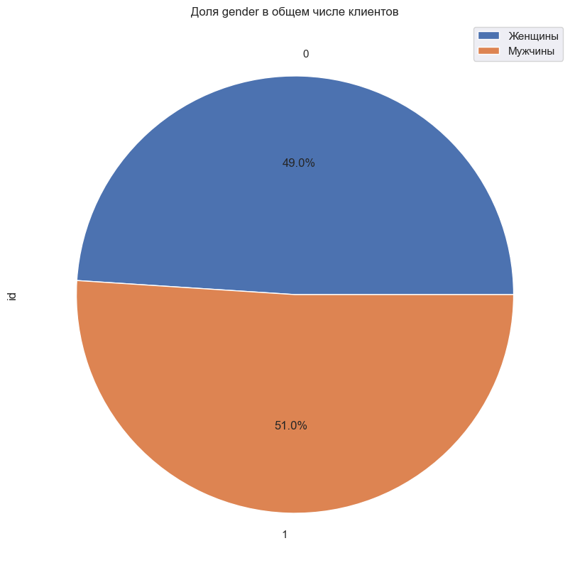

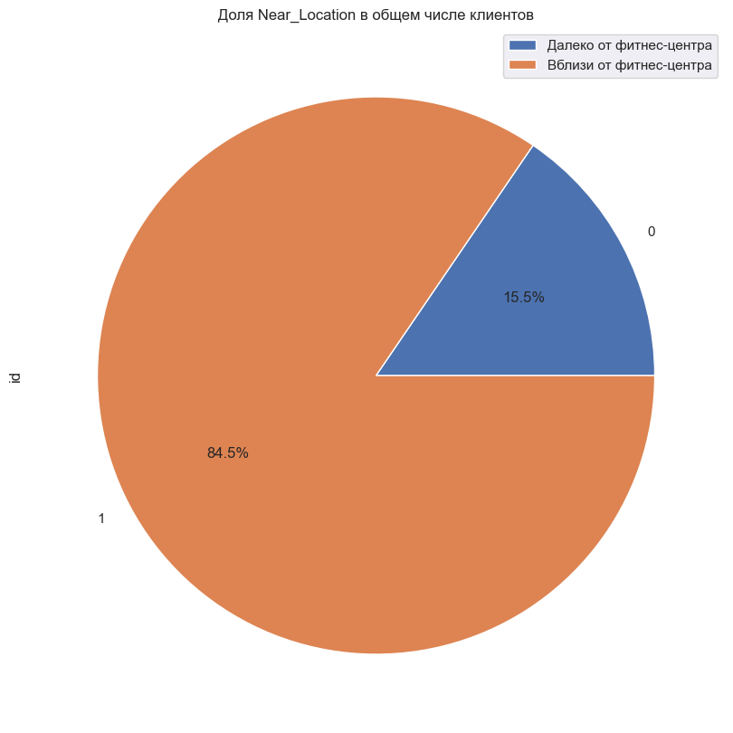

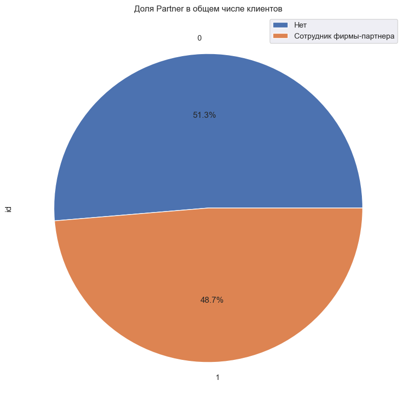

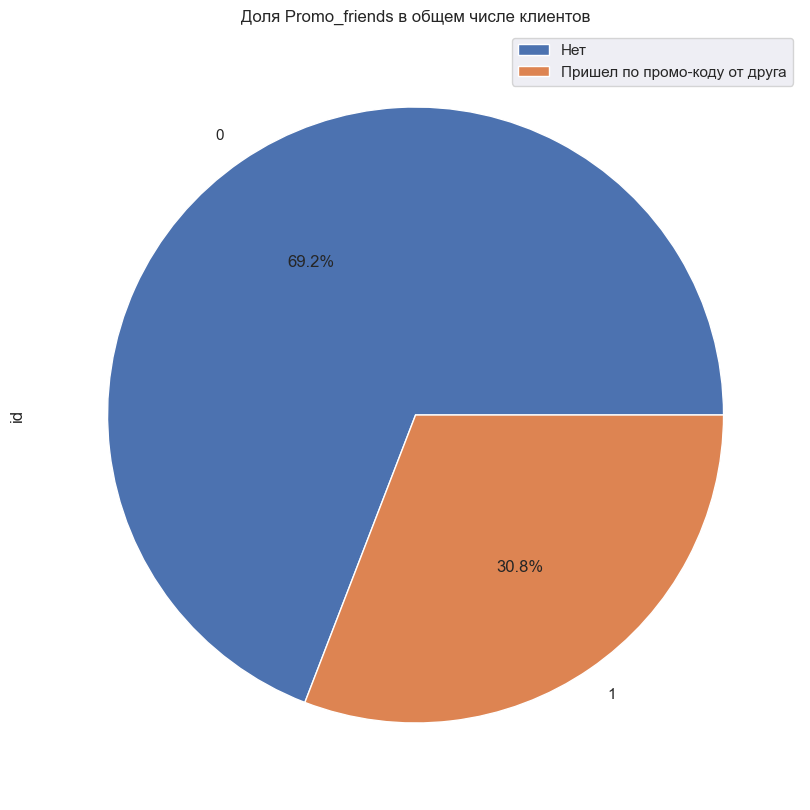

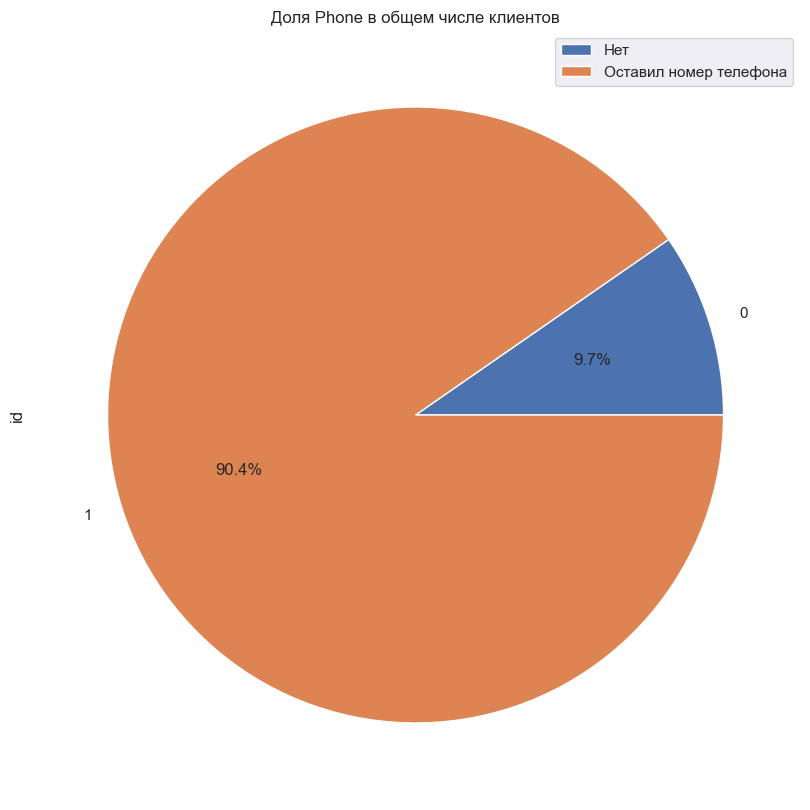

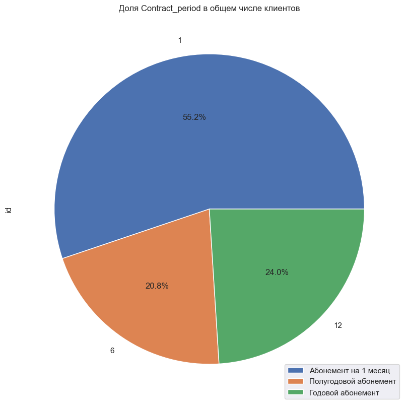

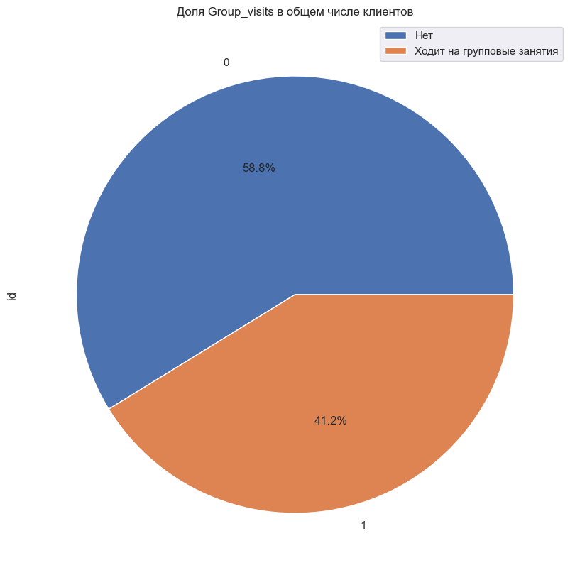

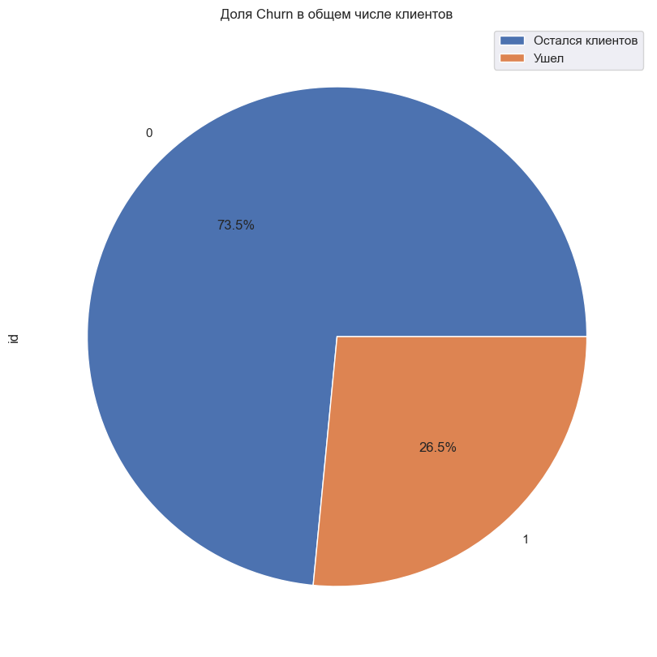

```python
for key, value in cat_names.items():
    pie_cat(gym, key, key, 'id', legend = value)
```

**Первый взгляд на характеристики клиентов:**

- **27%** наблюдений в выборке - это ушедшие клиенты.
- Медианный возраст клиента - **29 лет**, старше 41 нет никого, пенсионеры в нашу сеть фитнес-центров не ходят.
- Гендерный баланс в выборке **в целом соблюден**, так как доп информации к массиву нам не предоставлено, мы будем считать, что 0 - женщина, 1 - мужчина.
- Медианный клиент тренируется **чуть реже 2 раз в неделю**. В последний месяц при этом тренировки были **чуть реже**.
- Более половины клиентов в выборке покупают **месячные** абонементы, около четверти - **годовые**, порядка 20% - **полугодовые**.
- У **большинства** клиентов в массиве свежекупленные абонементы.
- В среднем клиенты оставляют в доп сервисах фитнес-центров порядка **140 рублей в месяц**.
- Большинство клиентов **живут поблизости** от фитнес-центров, в которые ходят.
- **Почти половина** клиентов в выборке пришли по партнерским программам.
- **Менее трети** клиентов пришли по промокодам от друзей.
- **9/10** клиентов предоставили номера своих телефонов.
- **Менее половины** клиентов посещают групповые занятия.

Вернуться к оглавлению

### Сравнение групп клиентов

Далее сравним ушедших и не ушедших клиентов

Создадим новый словарь с исследуемыми признаками

```python
cat_names_2 = cat_names
del cat_names_2['Churn']
del cat_names_2['Contract_period']

for key, value in cat_names_2.items():
    cat_names_2[key].pop(0)

cat_names_2
```

```
{'gender': ['Мужчины'],
 'Near_Location': ['Вблизи от фитнес-центра'],
 'Partner': ['Сотрудник фирмы-партнера'],
 'Promo_friends': ['Пришел по промо-коду от друга'],
 'Phone': ['Оставил номер телефона'],
 'Group_visits': ['Ходит на групповые занятия']}
```

```python
def bar_cat(category, name, legend):
    temd_df_3 = gym.pivot_table(index = category, values = 'id', columns = 'Churn', aggfunc = 'count')
    temd_df_3[0] = temd_df_3[0]/temd_df_3[0].sum()
    temd_df_3[1] = temd_df_3[1]/temd_df_3[1].sum()
    temd_df_3 = temd_df_3.transpose()
    temd_df_3 = temd_df_3.drop(0, axis = 1)
    temd_df_3 = temd_df_3.transpose()
    ax = sns.barplot(data=temd_df_3)
    plt.legend(legend)
    plt.title('Доля {} в общем числе ушедших и оставшихся клиентов'.format(legend))
    ax.set_xlabel('Клиент не ушел Vs. клиент ушел', fontsize=15)
    ax.set_ylabel('Доля', fontsize=15)
    plt.show()
```

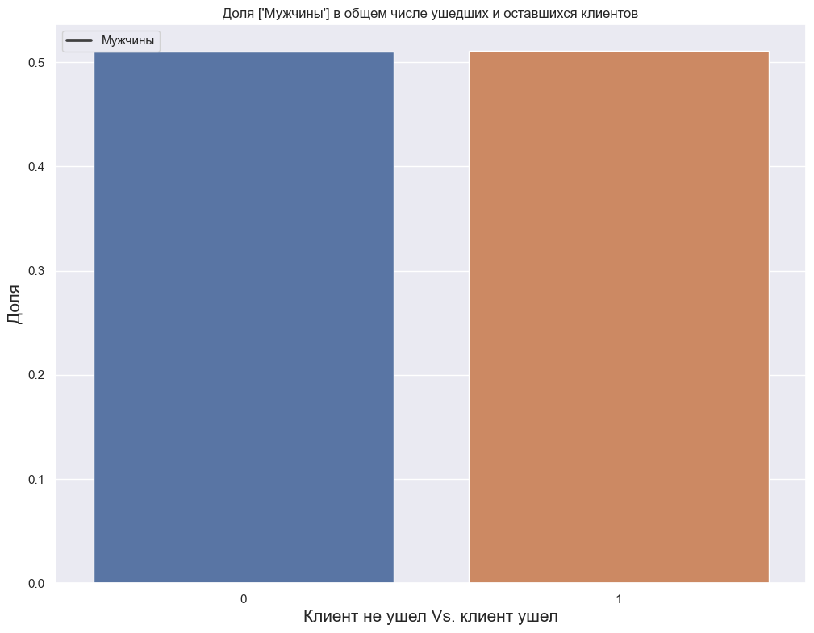

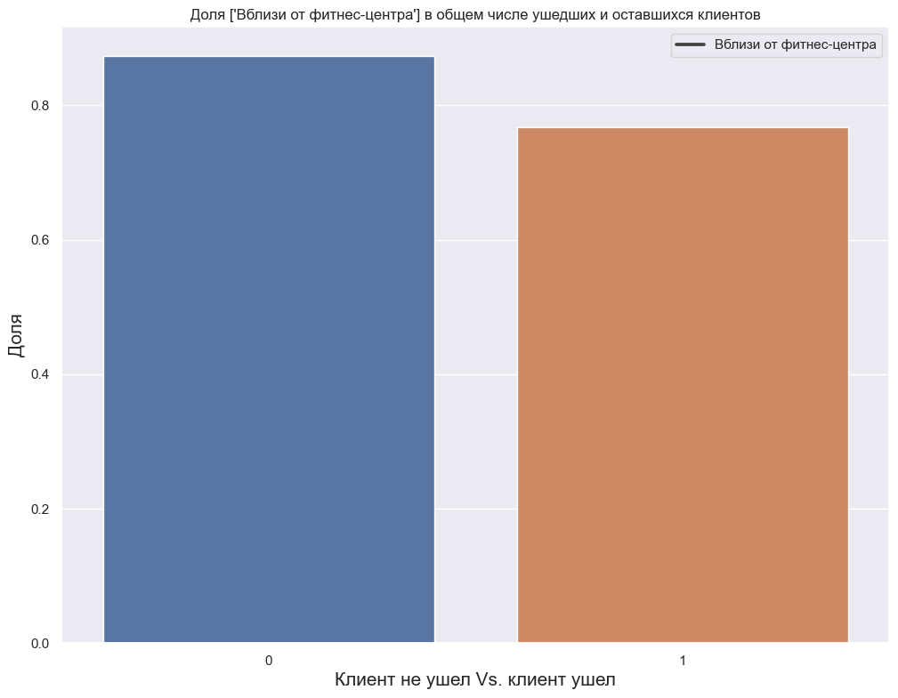

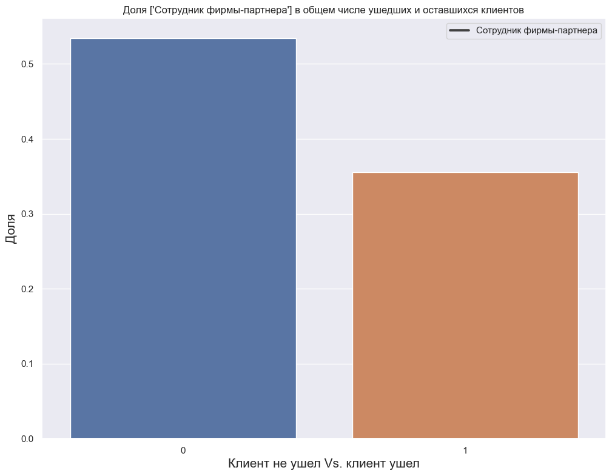

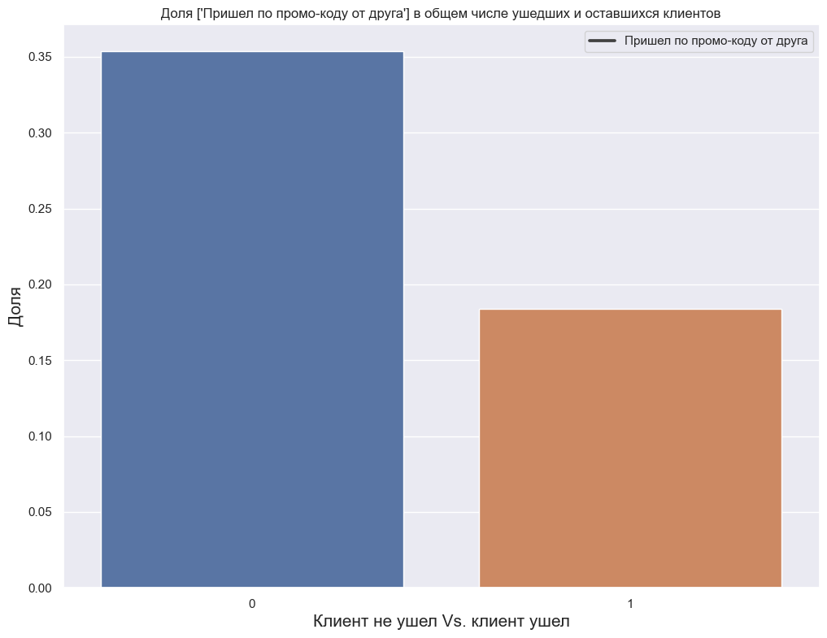

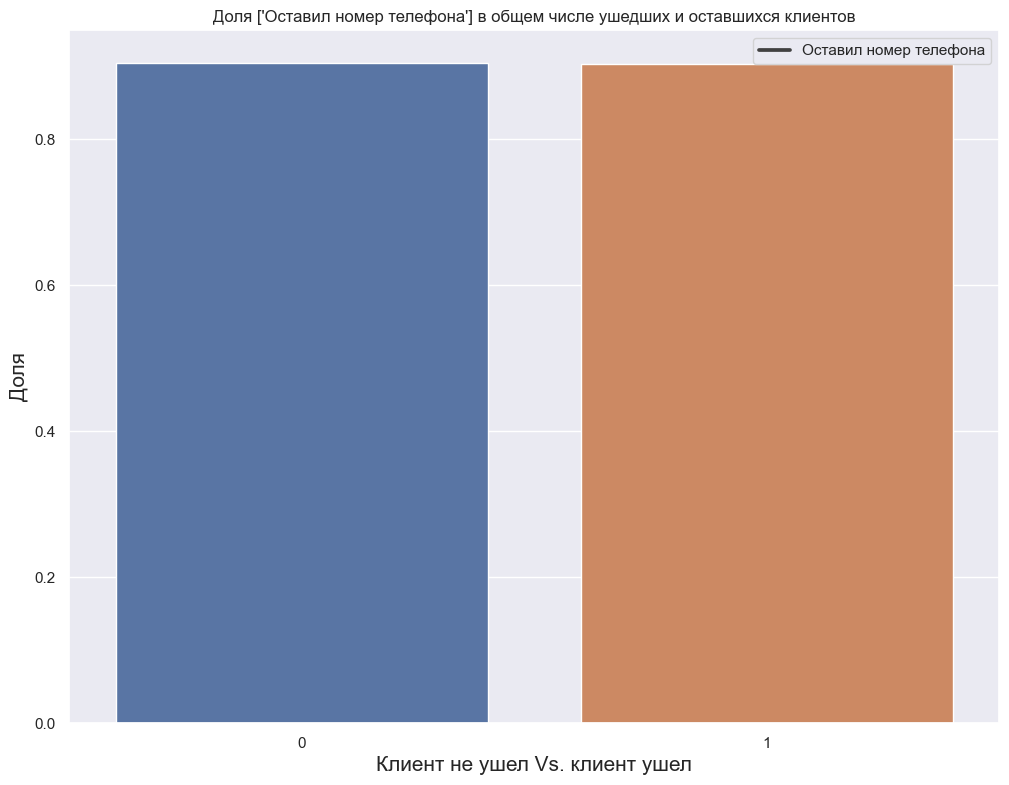

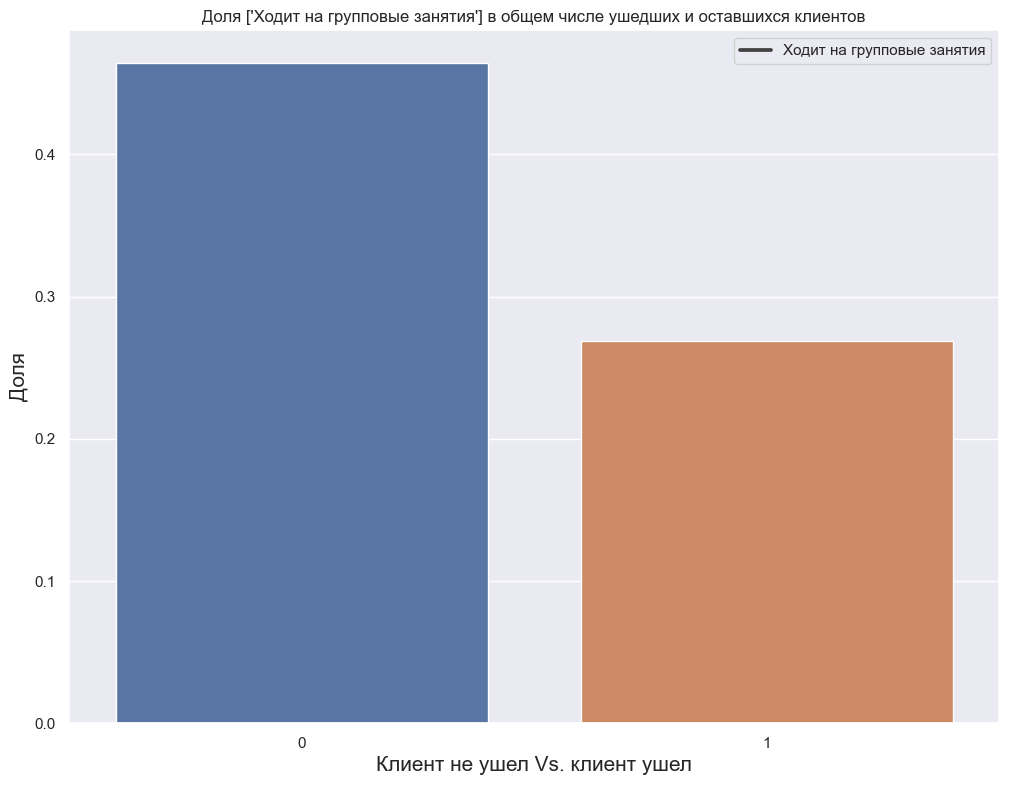

```python
for key, value in cat_names_2.items():
    bar_cat(key, key, legend = value)
```

**Итак, первые графики нам показывают, что:**

- Гендерный баланс среди оставшихся и ушедших клиентов соблюдается
- Ушедшие клиенты чаще живут далеко от фитнес-центра, дорога занимает больше времени и они забрасывают тренировки.
- Среди оставшихся клиентов больше доля тех, кто пришел по скидочной программе - от друга или компании-партнера, в первом случае клиент возможно ходит на тренировки не один и это его подстгивает, во втором корпоративная скидка делает конкретно нашу сеть центров для клиента дешевле, чем остальные, что не дает ему уйти к конкурентам.
- Клиенты, которые ходят на групповые занятия уйдут с меньшей вероятностью, поскольку более вовлечены в тренировки.
- Телефон оставляют клиенты из обеих групп.

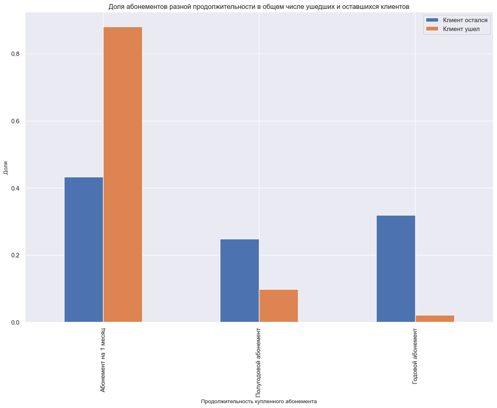

```python
temd_df_4 = gym.pivot_table(index = 'Contract_period', values = 'id', columns = 'Churn', aggfunc = 'count')
temd_df_4[0] = temd_df_4[0]/temd_df_4[0].sum()
temd_df_4[1] = temd_df_4[1]/temd_df_4[1].sum()
abnmt = ['Абонемент на 1 месяц','Полугодовой абонемент','Годовой абонемент']
temd_df_4['abnmt'] = abnmt
temd_df_4.set_index('abnmt', drop = True, inplace = True)
ax = temd_df_4.plot.bar(figsize = (15,10))
plt.legend(['Клиент остался', 'Клиент ушел'])
plt.title('Доля абонементов разной продолжительности в общем числе ушедших и оставшихся клиентов')
ax.set_xlabel('Продолжительность купленного абонемента', fontsize=10)
ax.set_ylabel('Доля', fontsize=10)
```

Далее мы видим, что, вполне ожидаемо, распространен сценарий "Клиент взял абонемент на 1 месяц попробовать, ему что-то не понравилось, после чего он перестал ходить". Лояльные клиенты чаще берут долгосрочные абонементы.

```python
def bar_cat_mean(value, name):
    temd_df_4 = gym.pivot_table(index = 'Churn', values = value, aggfunc = 'mean')
    temd_df_4 = temd_df_4.reset_index(level=0)
    ax = sns.barplot(data=temd_df_4, x = 'Churn', y = value)
    #plt.legend(legend)
    plt.title('Среднеее значение переменной {} среди ушедших и оставшихся клиентов'.format(name))
    ax.set_xlabel('Клиент не ушел Vs. клиент ушел', fontsize=15)
    ax.set_ylabel('Среднее значение', fontsize=15)
    plt.show()
```

```python
mean_names = {'Age':'"Возраст"',
              'Avg_additional_charges_total':'"Среднее количество денег, потраченных на доп сервисы"',
              'Month_to_end_contract':'"Количество месяцев до конца абонемента"',
              'Lifetime':'"Количество месяцев с начала текущего абонемента"',
              'Avg_class_frequency_total':'"Среднее количество тренировок в неделю"',
              'Avg_class_frequency_current_month':'"Среднее количество тренировок в неделю за прошлый месяц"'

}
```

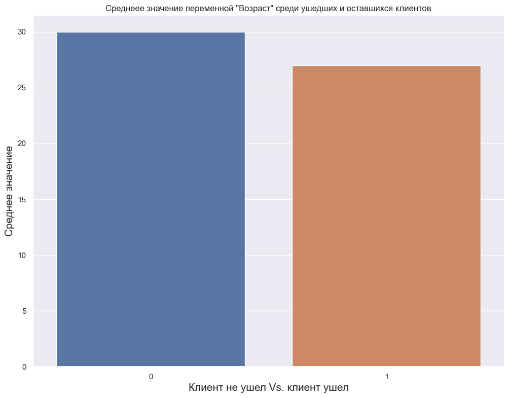

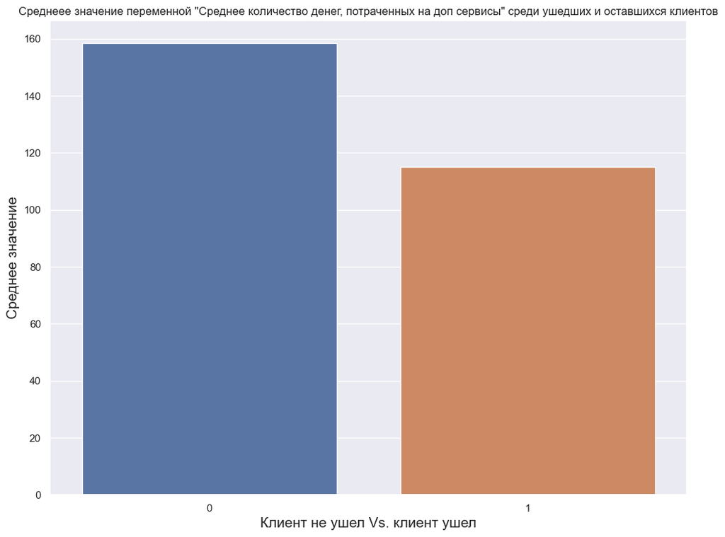

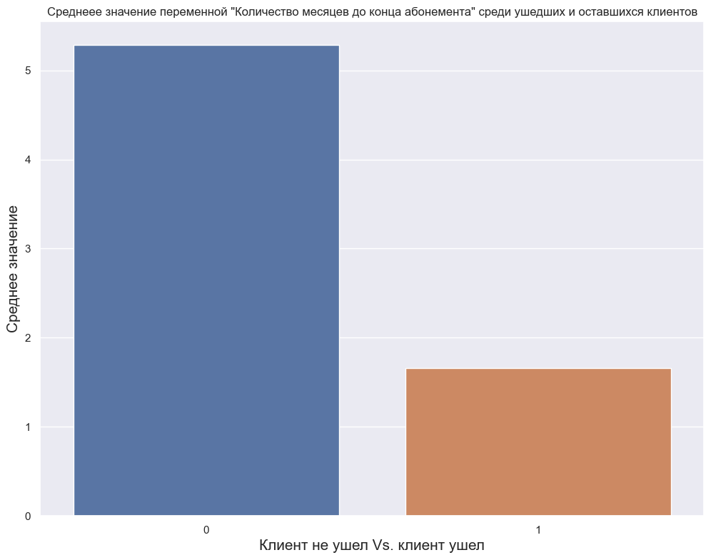

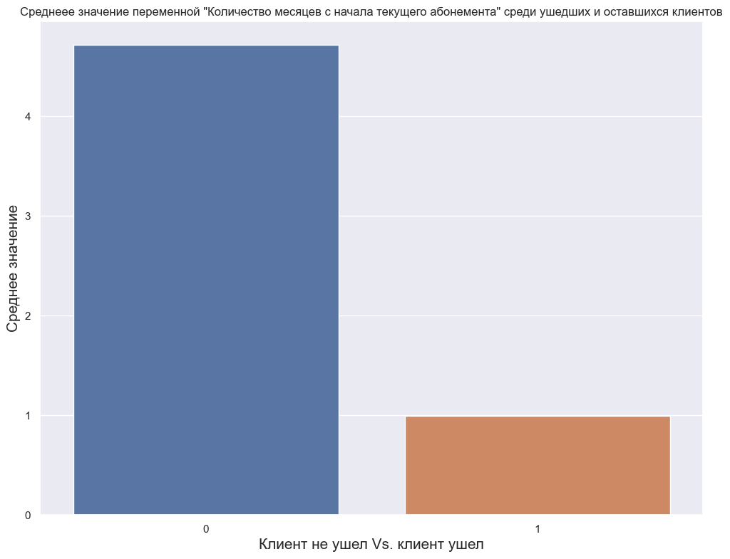

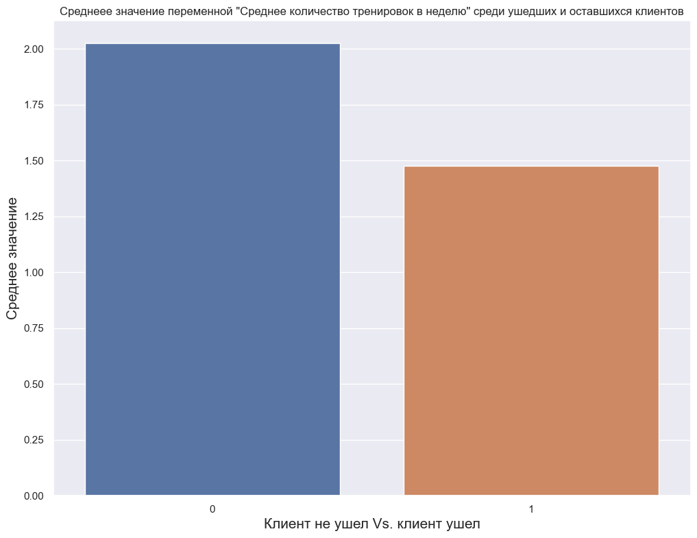

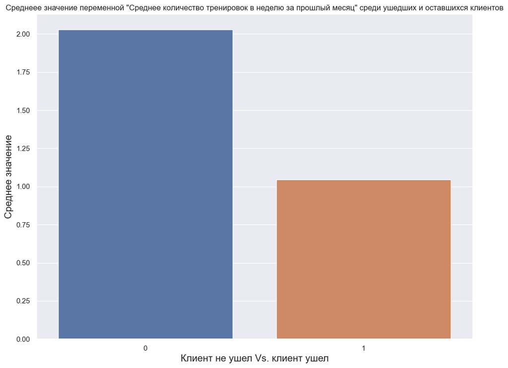

```python
for key, value in mean_names.items():
    bar_cat_mean(key, value)
```

**На следующих графиках показано, что:**

- Лояльные клиенты старше.
- Лояльные клиенты тратят больше денег на дополнительные сервисы в фитнес-центре.
- Лояльные клиенты тренируются чаще.
- Уходящие клиенты в месяц перед уходом начинают тренироваться реже, то есть их спортивная активность затухает постепенно.
- В соответствии с предыдущим графиком про типы абонементов, мы видим, что у лояльных клиентов прошло в среднем больше месяца с покупки абонемента и осталось больше месяцев до его окончания - просто потому что лояльные клиенты берут длинные абонеменеты.

Вернуться к оглавлению